# Inferential Statistics - Course Project part 2

Maurizio Murino

29 January 2016

## Introduction

Now in the second portion of the class, we’re going to analyze the ToothGrowth data in the R datasets package.

## Data load, exploration and summary

*Points 1 and 2.*

```r
"datasets" %in% row.names(installed.packages())
```

```
## [1] TRUE
```

```r
library(datasets)
data("ToothGrowth")
dim(ToothGrowth)
```

```
## [1] 60  3
```

```r
class(ToothGrowth)
```

```
## [1] "data.frame"
```

```r
str(ToothGrowth)
```

```
## 'data.frame':    60 obs. of  3 variables:
##  $ len : num  4.2 11.5 7.3 5.8 6.4 10 11.2 11.2 5.2 7 ...
##  $ supp: Factor w/ 2 levels "OJ","VC": 2 2 2 2 2 2 2 2 2 2 ...
##  $ dose: num  0.5 0.5 0.5 0.5 0.5 0.5 0.5 0.5 0.5 0.5 ...
```

```r
summary(ToothGrowth)
```

```
##       len        supp         dose
##  Min.   : 4.20   OJ:30   Min.   :0.500
##  1st Qu.:13.07   VC:30   1st Qu.:0.500
##  Median :19.25           Median :1.000
##  Mean   :18.81           Mean   :1.167
##  3rd Qu.:25.27           3rd Qu.:2.000
##  Max.   :33.90           Max.   :2.000
```

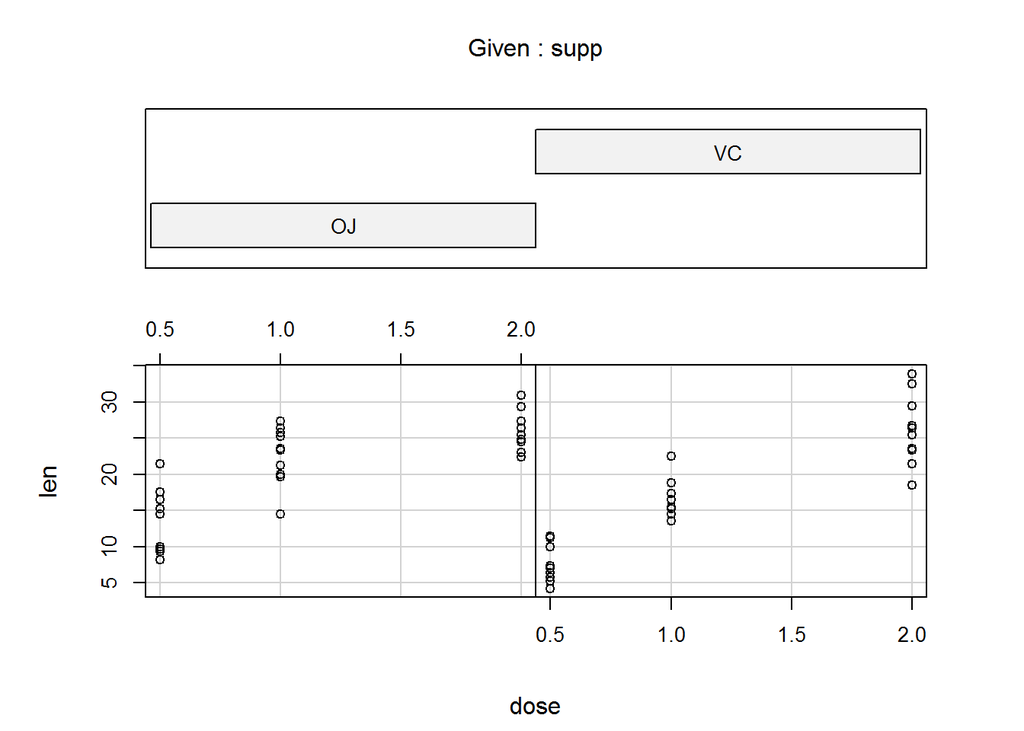

```r
with(ToothGrowth, coplot(len ~ dose | supp))
```

The plot shows the response in the length of odontoblasts (cells responsible for tooth growth) in 60 guinea pigs. Each animal received one of three dose levels of vitamin C (0.5, 1, and 2 mg/day) by one of two delivery methods, (orange juice or ascorbic acid (a form of vitamin C and coded as VC).

## Confidence intervals/hypothesis tests.

*Use confidence intervals and/or hypothesis tests to compare tooth growth by supp and dose. (Only use the techniques from class, even if there’s other approaches worth considering).*

Vitamin C delivery methods affect the tooth length of the guinea pigs? H0: true difference in means is equal to zero.

### t-test

```r
with(ToothGrowth, t.test(len[supp=="OJ"], len[supp=="VC"], paired = FALSE, var.equal = FALSE))
```

```
##
##  Welch Two Sample t-test
##
## data:  len[supp == "OJ"] and len[supp == "VC"]
## t = 1.9153, df = 55.309, p-value = 0.06063
## alternative hypothesis: true difference in means is not equal to 0
## 95 percent confidence interval:
##  -0.1710156  7.5710156
## sample estimates:
## mean of x mean of y
##  20.66333  16.96333
```

P-value of this test is 0.06. It could be interpreted as a lack of evidence to reject the null hypothesis. We cannot assume that the vitamin delivery method affect the tooth length.

Same t test for the tooth length of the group with vitamin C dosage.

```r
with(ToothGrowth, t.test(len[dose==2], len[dose==1], paired = FALSE, var.equal = TRUE))
```

```
##
##  Two Sample t-test
##
## data:  len[dose == 2] and len[dose == 1]
## t = 4.9005, df = 38, p-value = 1.811e-05
## alternative hypothesis: true difference in means is not equal to 0
## 95 percent confidence interval:
##  3.735613 8.994387
## sample estimates:
## mean of x mean of y
##    26.100    19.735
```

We can reject the null hypothesis. As consequence, we can assume that the means of dosage change from 1mg to 2mg creates an positive effect on tooth length.

## Conclusions

*State your conclusions and the assumptions needed for your conclusions.*

I suppose that Guinea pigs were randomly assigned to random treatments. Hence, the tests used a methodology adapt to indipendent samples.

The method of supplement has appearently a limitate effect on tooth growth. More relevant is the increase of the dosage, which leads to an increased tooth growth.